# Semesterproject paper

Aurelia Möri, Lisa Wahlen

2023-07-04

## Introduction

Mountain biking can be practiced on different surfaces (on or off-road), there is a preference for natural areas (Zajc & Berzelak, 2016).

In this project, we aim at defining criteria that indicate mountainbiking movement patterns, and try to provide information about the characteristics of mountainbiking.

what are characteristics of mountainbiking? -> downhill (not uphill), in vegetated areas / trails (not on streets), within a certain speed range.

In order to filter the mountainbiking pattern, we defined three criteria with which we should be able to have a unique identifier. Those three criteria consist of the speed with which the person is moving, the groundtype on which the trajectory is laying and furthermore the steepness of the trajectory, which needs to be directed downhill. Using just one or two of the criteria will always still allow for other activities. Such that a trajectory placed on grass and in forests could still also be a hiker, which also applies to the downhill movement. The Speed of a mountainbiker is hard to define, but it is also not a unique identifier for this movement pattern.

## Research Question

In this paper we will work on the following two research questions:

- Which criteria can be used to characterize the movement pattern of downhill mountainbiking?
- Are the chosen criteria applicable to other movement trajectories?

## Data and Methods

### Datasets

For the project, I used the movement trajectories that were created by Lisa Wahlen when going mountainbiking. The trajectories were recorded by using the GPS-tracking App posmo (Genossenschaft Posmo Schweiz, 2022) with a sampling rate of 10 seconds. We include 3 mountainbiking tours Lisa completed in the period from the 6th of May to the 18th of May 2023. The tours were recorded in Switzerland in the areas of Wiriehorn (2 tours) and Valbirse (1 tour).

For the assessment of the criteria that describe the movement pattern of mountain biking, we used the MOPUBE vector dataset providing the land cover types of the canton of Bern, using the version last updated on the 23.05.23 (Amt für Geoinformation des Kantons Bern, 2023). In addidtion, we worked with parts of the swiss digital terrain model swissALTI3D (Bundesamt für Landestopografie swisstopo, 2022). This elevation data is provided as raster in a resolution of 0.5 m in grids of 1 km2. We worked with extracts of the datasets, covering the spatial extent of the trajectories within the Canton of Bern.

We chose the tour Lisa made on the 18th of May in the Wiriehorn area (Wiriehorn 05-18) to define the characteristics of the biking movement pattern and tried to apply the criteria to the tour at Wiriehorn on the 7th of May (Wiriehorn 05-07) and the tour in Valbirse on the 6th of May for verification. The trajectories included the car ride from Solothurn to the biking location and back. A first visualisation of transport modes of the data revealed that the mountainbiking part of the trajectories were labelled by the posmo app as “Car”, “Bus”, “Other” - and sometimes almost correctly with “Bike”.

**Wiriehorn trajectory of the 18th of May**  
*Navigating to the south of the trajectory you’ll find the mountainbiking part.*

[interactive chart not shown]

**Wiriehorn trajectory of the 7th of May**  
*Navigating to the south of the trajectory you’ll find the mountainbiking part.*

[interactive chart not shown]

**Valbirse trajectory of the 6th of May**  
*Navigating to the northeast of the trajectory you’ll find the mountainbiking part.*

[interactive chart not shown]

### Preprocessing

All datasets of the trajectories were first converted to a georeferenced feature. Temporal outliers recorded the night before the trip started were removed, as well as unnecessary or redundant information about Lisa’s user ID, the weekday, or the place name.

### Methods

#### Speed and segmentation

For every fix on the trajectory I calculated the average speed within the window of four neighboring points, similar to the moving window method of Laube & Purves (2011). The euclidean distance to the two points before and the two points after the fix was calculated and divided by the time difference between the fix and the two points before and after, respectively. Fixes where the speed calculation could not be completed because either the distance or the time between two points was 0, were regarded as static. On the Wiriehorn 05-18 tour, 80 points were labelled as static, and used for segmentation of the trajectory. They were located in places on the trajectory where little movement or a change in transport mode is plausible (e.g. at the bottom and the top of the cable car allmiried, somewhere in the middle of the downhill trail, at train stations in Solothurn).

The extraction of the mountainbiking parts of the trajectory was based on visual assessment of the movement parameter profile based on Dodge et al. (2009) for the average speed.

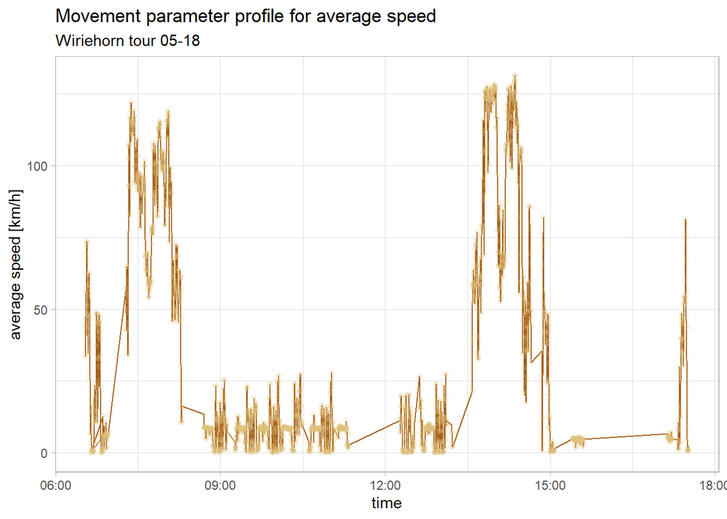

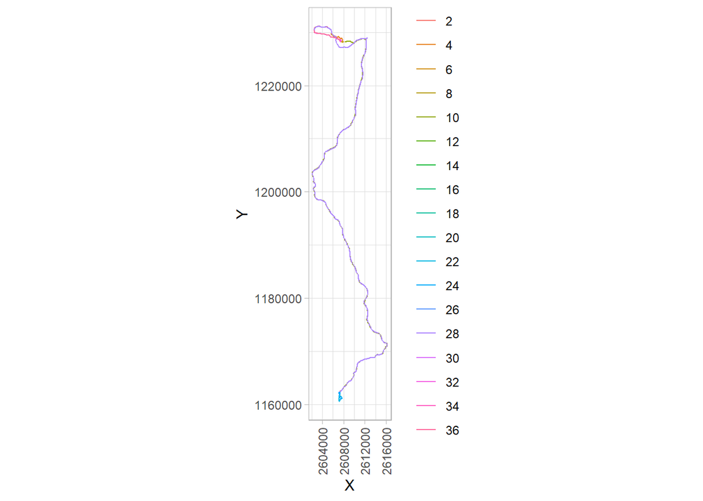

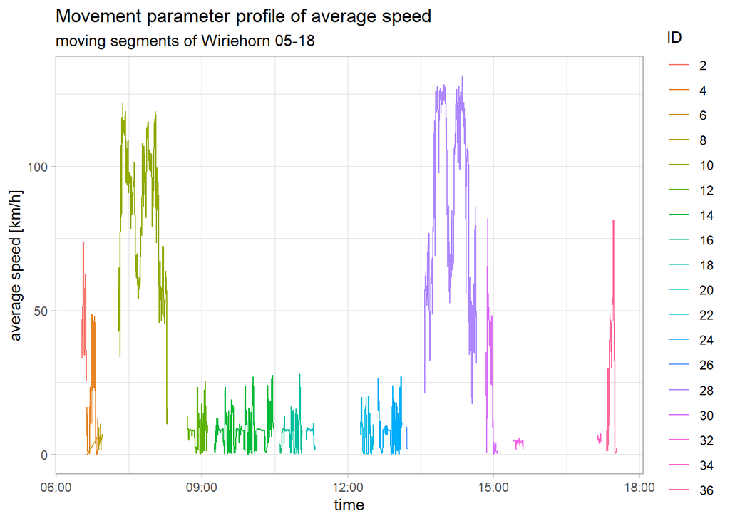

MPP before and after segmentation

However, the selected segments included the movement of the cable car Lisa took to get uphill to the trail start. To isolate the cable car and determine the relevant speed range for mounainbiking, the average speed distribution of the selected segments was calculated. The speed values that best characterized the movement of mountain biking were identified through a process of testing.

#### Ground cover

To determine on which parts of the trajectory Lisa moved offroad, I intersected the ground cover dataset MOPUBE and the movement points. This reduced the trajectories to the spatial extent of the Canton of Bern, therefore excluding parts of the car ride from and to Solothurn. This step called track annotation (Dodge et al., 2013) allowed to add environmental information to the points on the trajectory. All points associated with natural ground cover were considered as matching the criteria and labelled accordingly.

#### Downhill movement

The elevation data was added to the dataset of the Wiriehorn 05-18 trajectory and the difference in elevation to the next point within a 40 second window in the direction of movement was calculated. If within this 40 second window the difference in altidude was negative, it is assumed to be downhill movement.

#### Combination of all criteria

For every point on the trajectory I displayed how many of the three criteria applied. Based on the count of matching criteria, I isolated new segments that represent downhill mountainbiking according to the following conditions: The neighboring four fixes must show a sum of at least 6 matched criteria, and, within one Minute, there is at least one fix that matches all three of the criteria.

### Limitations

- we should try our code on another mountainbike pattern from Lisa to find whether its applicable to all patterns.
- visually choosing relevant segments
- quantyfying mountainbiking points, evaluation
- cable car within segments. no segments only including biking
- speed range chosen to exclude cable car.

## Results

### Speed

The average Speed on the Allmiried tour was 37.33548 km/h. The biking segments (including the cable car) showed an average speed of 7.80428 km/h. Since Lisa took the cable car several times on the Allmiried tour, the second and the third quartile of the speed distribution represent the speed of the cable car. In consequence, the first and the fourth quartile of the distribution were chosen to represent mountainbiking, resulting in a range of speed values from 0 to 2.855 and from 10.308 to 26.95490. These criteria also preserve the transport mode “walking”.

## Discussion

track annotation with environmental data (Dodge et al., 2013) GlobCover (http://due.esrin.esa.int/page_globcover.php) is from 2009, MOPUBE is updated weekly.

## References

Amt für Geoinformation des Kantons Bern. (2023). *Amtliche Vermessung vereinfacht* [Map]. 2023https://www.agi.dij.be.ch/de/start/geoportal/geodaten/detail.html?type=geoproduct&code=MOPUBE

Bundesamt für Landestopografie swisstopo. (2022). *swissALTI3D: das hochaufgelöste Terrainmodell der Schweiz* [Map]. https://www.swisstopo.admin.ch/de/geodata/height/alti3d.html

Dodge, S., Weibel, R., & Forootan, E. (2009). Revealing the physics of movement: Com- paring the similarity of movement characteristics of different types of moving objects. *Computers, Environment and Urban Systems, 33*(6), 419–434. https://doi.org/10.1016/j.compenvurbsys.2009.07.008

Dodge, S., Bohrer, G., Weinzierl, R., Davidson, S. C., Kays, R., Douglas, D., Cruz, S., Han, J., Brandes, D. & Wikelski, M. (2013). The environmental-data automated track annotation (Env-DATA) system: linking animal tracks with environmental data. *Movement Ecology, 1*(1), 3. https://doi.org/10.1186/2051-3933-1-3

Fischer, A., Lamprecht, M., & Bürgi, R. (2021). *Mountainbiken in der Schweiz 2020: Auswertung Mountainbikeland-Befragung 2019 und Sekundäranalyse von «Sport Schweiz 2020»*. Bundesamt für Strassen ASTRA und Stiftung SchweizMobil. https://www.astra.admin.ch/astra/de/home/themen/langsamverkehr/materialien.html

Genossenschaft Posmo Schweiz. (2022). *Posmo Project App - Tracking für Gruppen*. https://posmo.coop/produkte/posmo-project-tracking-fuer-gruppen

Laube, P. (2014). *Computational Movement Analysis*. Springer Cham. https://doi.org/10.1007/978-3-319-10268-9

Laube, P. & Purves, R.(2011) How fast is a cow? Cross-scale Analysis of Movement Data, *Transactions in GIS, 15*(3), 401–418, John Wiley & Sons Ltd, DOI: 10.1111/j.1467-9671.2011.01256.x

*Dodge, S., Laube, P., & Weibel, R. (2012). Movement similarity assessment using symbolic representation of trajectories.* International Journal of Geographical Information Science, 26*(9), 1563-1588. https://doi.org/10.1080/13658816.2011.630003*

Pröbstl-Haider, U., Lund-Durlacher, D., Antonschmidt, H. & Hödl, C. (2018). Mountain bike tourism in Austria and the Alpine region – towards a sustainable model for multi-stakeholder product development. *Journal of Sustainable Tourism, 26*(4), 567-582. https://doi.org/10.1080/09669582.2017.1361428

Zajc, P. & Berzelak, N. (2016). Riding styles and characteristics of rides among Slovenian mountain bikers and management challenges. *Journal of Outdoor Recreation and Tourism, 15*, 10-19. https://doi.org/10.1016/j.jort.2016.04.009